# Machine Learning Project 1

Brent Kuenzi

December 23, 2015

# Synopsis

Using data generated from accelerometers on the belt, forearm, arm, and dumbell of 6 participants who were asked to perform barbell lifts correctly and incorrectly in 5 different ways. The goal of this project is to predict the manner in which they did the exercise.

# Data and Dependencies

Lets start by loading the data and required packages

```r
library(caret); library(ggplot2); library(dplyr); library(corrplot)
library(doParallel)
registerDoParallel(cores=2)

train_set <- read.csv(file="pml-training.csv")
test_set <- read.csv(file="pml-testing.csv")
```

# Preprocessing

First we will split the **training** set into *test* and *train* set for accuracy predictions. Then will will perform some basic preprocessing. For ease of use, we will perform the following preprocessing steps:

```r
set.seed(1234); library(randomForest)
inTrain <- createDataPartition(y=train_set$classe, p=0.7, list=FALSE)
cv_train <- train_set[inTrain,]
cv_test <- train_set[-inTrain,]
```

There are lots of columns with mostly NA values and these should be removed as they will not be useful for prediction

```r
test_NA <- sapply(cv_test, function(x) {sum(is.na(x))})
table(test_NA)
```

```
## test_NA
##    0 5763
##   93   67
```

```r
# remove columns of all NA values
train_col2 <- cv_train[, colSums(is.na(test_set)) != 20] # validation set
train_col <- train_col2[, colSums(is.na(train_col2)) != 13453] # cv test set
# remove unnecessary timestamp and factor variables
train <- train_col[,-(1:6)]
train[,1:53] <- as.data.frame(sapply(train[,1:53], function(x) {as.numeric(x)}))
# Same with test set
test <- cv_test[, colnames(cv_test) %in% colnames(train)]
test[,1:53] <- as.data.frame(sapply(test[,1:53], function(x) {as.numeric(x)}))
```

# Data Exploration

A number of variables within the training set seem to be highly correlated. This should allow modeling to create a rather robust prediction.

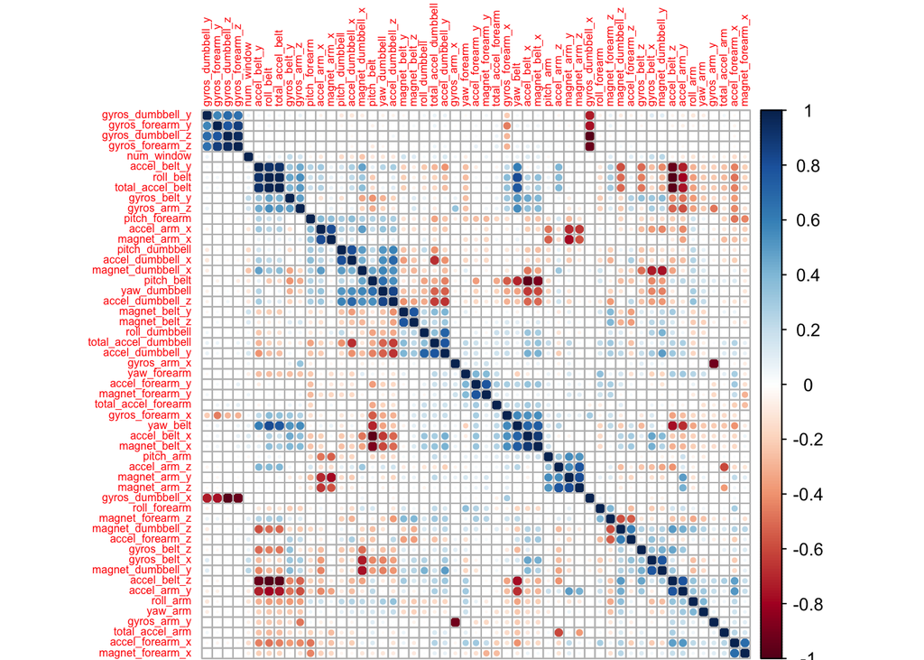

```r
corrs <- cor(subset(train, select=-c(classe)))
corrplot(corrs, order="hclust", tl.cex=0.5)
```

# Model Building and Evaluation

We will now create a model to predict the *classe* variable using a random forest model

```r
MyTrainControl=trainControl(
  method = "cv",
  number=5,
  returnResamp = "all",
   classProbs = TRUE
)
model2 <- train(classe~., method="parRF", trControl = MyTrainControl, data=train)
```

```r
modFit <- predict(model2,newdata=test)
confusionMatrix(modFit,test$classe)
```

```
## Confusion Matrix and Statistics
##
##           Reference
## Prediction    A    B    C    D    E
##          A 1674    4    0    0    0
##          B    0 1134    2    0    0
##          C    0    1 1024    1    0
##          D    0    0    0  963    1
##          E    0    0    0    0 1081
##
## Overall Statistics
##
##                Accuracy : 0.9985
##                  95% CI : (0.9971, 0.9993)
##     No Information Rate : 0.2845
##     P-Value [Acc > NIR] : < 2.2e-16
##
##                   Kappa : 0.9981
##  Mcnemar's Test P-Value : NA
##
## Statistics by Class:
##
##                      Class: A Class: B Class: C Class: D Class: E
## Sensitivity            1.0000   0.9956   0.9981   0.9990   0.9991
## Specificity            0.9991   0.9996   0.9996   0.9998   1.0000
## Pos Pred Value         0.9976   0.9982   0.9981   0.9990   1.0000
## Neg Pred Value         1.0000   0.9989   0.9996   0.9998   0.9998
## Prevalence             0.2845   0.1935   0.1743   0.1638   0.1839
## Detection Rate         0.2845   0.1927   0.1740   0.1636   0.1837
## Detection Prevalence   0.2851   0.1930   0.1743   0.1638   0.1837
## Balanced Accuracy      0.9995   0.9976   0.9988   0.9994   0.9995
```

The result of the model shows that the accuracy is 99.8 %. The sensitivity and the specificity are higher than 99% for each class. We estimate our out of sample error to be 0.2%. Taking a look at the variables that were most important in prediction (below), we see that *num_window*, *roll_belt*, and *pitch_forearm* were the most important variables for this prediction model.

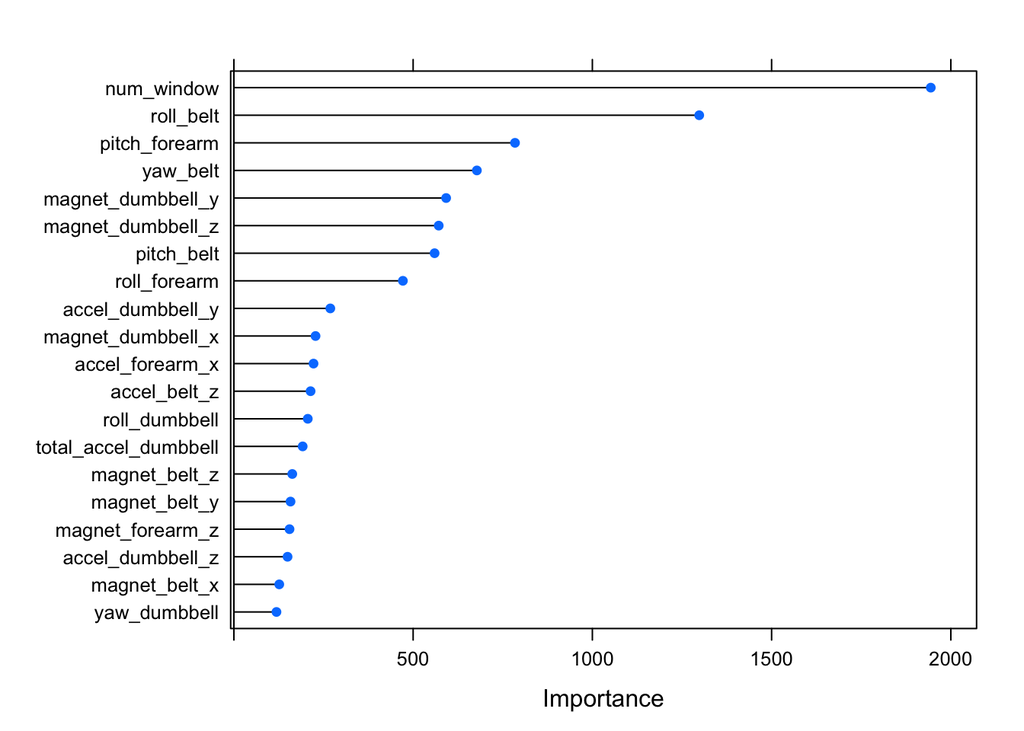

```r
plot(varImp(model2, scale=FALSE),top=20)
```

We can now apply this model to the test cases.

```r
test2 <- test_set[, colnames(test_set) %in% colnames(train)]
test2[,1:53] <- as.data.frame(sapply(test2[,1:53], function(x) {as.numeric(x)}))
pml_write_files = function(x){
  n = length(x)
  for(i in 1:n){
    filename = paste0("problem_id_",i,".txt")
    write.table(x[i],file=filename,quote=FALSE,row.names=FALSE,col.names=FALSE)
  }
}
modFit2 <- predict(model2,newdata=test2)
pml_write_files(modFit2)
```